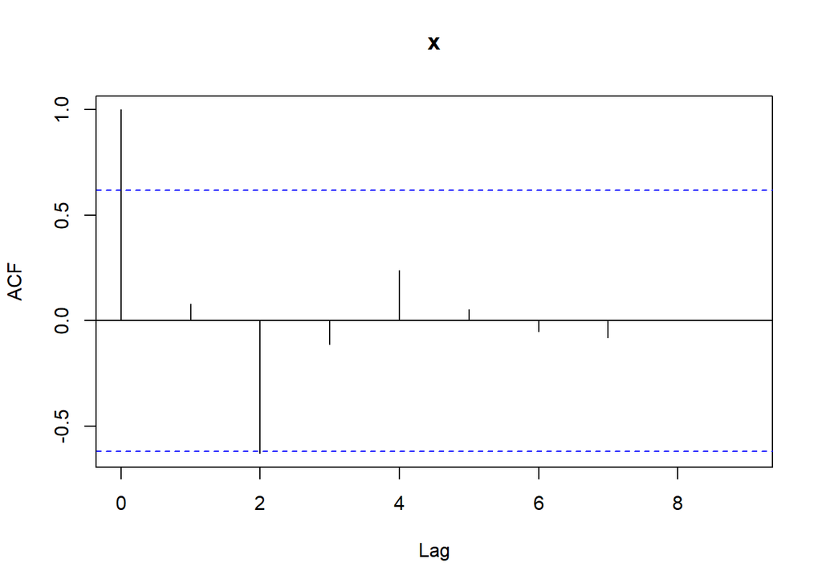

```r
acf(singapore_series_forecast2$residuals , lag.max = 20,na.action = na.pass)
```

```r
Box.test(singapore_series_forecast2$residuals,lag=7,type='Ljung-Box')#7 is the max number of lag that i can put considering the lenght of the datapoints(10)
```

```
##
##  Box-Ljung test
##
## data:  singapore_series_forecast2$residuals
## X-squared = 7.38815404697737765, df = 7, p-value = 0.38961371065466366
```

first create a function to get the distribution forecast errors:

```r
plotForecastErrors <- function(forecasterrors)
{
# make a histogram of the forecast errors:
mybinsize <- IQR(forecasterrors)/4
mysd <- sd(forecasterrors)
mymin <- min(forecasterrors) - mysd*5
mymax <- max(forecasterrors) + mysd*3
# generate normally distributed data with mean 0 and standard deviation mysd
mynorm <- rnorm(10000, mean=0, sd=mysd)
mymin2 <- min(mynorm)
mymax2 <- max(mynorm)
if (mymin2 < mymin) { mymin <- mymin2 }
if (mymax2 > mymax) { mymax <- mymax2 }
# make a red histogram of the forecast errors, with the normally distributed data overlaid:
mybins <- seq(mymin, mymax, mybinsize)
hist(forecasterrors, col="red", freq=FALSE, breaks=mybins)
# freq=FALSE ensures the area under the histogram = 1
# generate normally distributed data with mean 0 and standard deviation mysd
myhist <- hist(mynorm, plot=FALSE, breaks=mybins)
# plot the normal curve as a blue line on top of the histogram of forecast errors:
points(myhist$mids, myhist$density, type="l", col="blue", lwd=2)
}
```

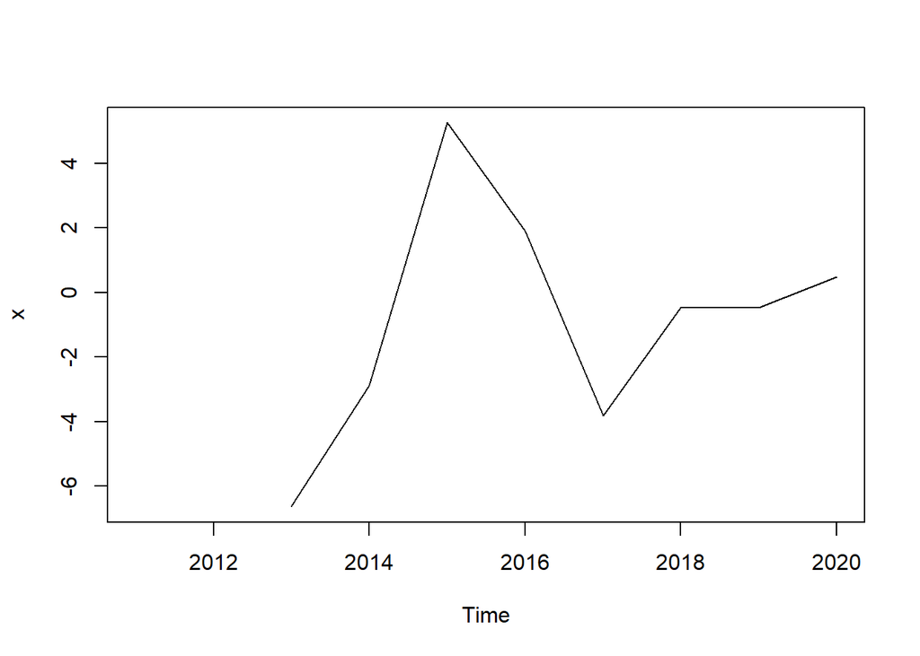

```r
plot(singapore_series_forecast2$residuals)
```

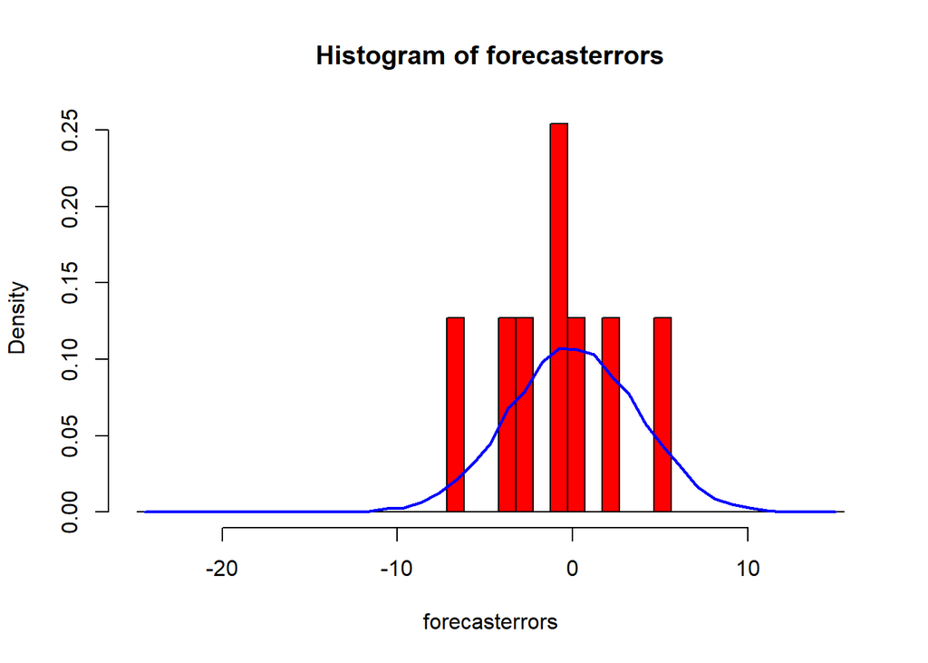

```r
singapore_series_forecast2$residuals=
  singapore_series_forecast2$residuals[!is.na(singapore_series_forecast2$residuals)]

plotForecastErrors(singapore_series_forecast2$residuals)
```

**ARIMA MODELS**

Exponential smoothing methods are useful for making forecasts, and make no assumptions about the correlations between successive values of the time series. However, if you want to make prediction intervals for forecasts made using exponential smoothing methods, the prediction intervals require that the forecast errors are uncorrelated and are normally distributed with mean zero and constant variance. While exponential smoothing methods do not make any assumptions about correlations between successive values of the time series, in some cases you can make a better predictive model by taking correlations in the data into account. Autoregressive Integrated Moving Average (ARIMA) models include an explicit statistical model for the irregular component of a time series, that allows for non-zero autocorrelations in the irregular component.

```r
colnames(data)
```

```
##  [1] "Country_Name"
##  [2] "Country_Code"
##  [3] "Time"
##  [4] "Access_to_electricity._percentage_of_pop"
##  [5] "Life_expectancy_at_birth"
##  [6] "Mortality_rate_under_5_per_1.000_live_births"
##  [7] "Political_Stability.Absence_of_Violence.Terrorism._Percentile_R"
##  [8] "Population_total"
##  [9] "Real_interest_rate_perc"
## [10] "Consumer_price_index_2010._100"
## [11] "GDP_US."
## [12] "GDP_per_Capita"
```

```r
Brazil_data <- developing_countries[developing_countries$Country_Name == 'Brazil', ( "Access_to_electricity._percentage_of_pop")]
Brazil_data <- as.data.frame(Brazil_data)
Brazil_data
```

```
##              Brazil_data
## 1  99.328691000000006284
## 2  99.519493999999994571
## 3  99.575151000000005297
## 4  99.650246999999993136
## 5  99.710902000000004364
## 6  99.700000000000002842
## 7  99.799999999999997158
## 8  99.700000000000002842
## 9  99.799999999999997158
## 10 99.702713009999996530
```

```r
Brazil_data_series=ts(Brazil_data,start = 2011)
Brazil_data_series
```

```
## Time Series:
## Start = 2011
## End = 2020
## Frequency = 1
##                 Brazil_data
##  [1,] 99.328691000000006284
##  [2,] 99.519493999999994571
##  [3,] 99.575151000000005297
##  [4,] 99.650246999999993136
##  [5,] 99.710902000000004364
##  [6,] 99.700000000000002842
##  [7,] 99.799999999999997158
##  [8,] 99.700000000000002842
##  [9,] 99.799999999999997158
## [10,] 99.702713009999996530
```

Check if the datat is stationary:

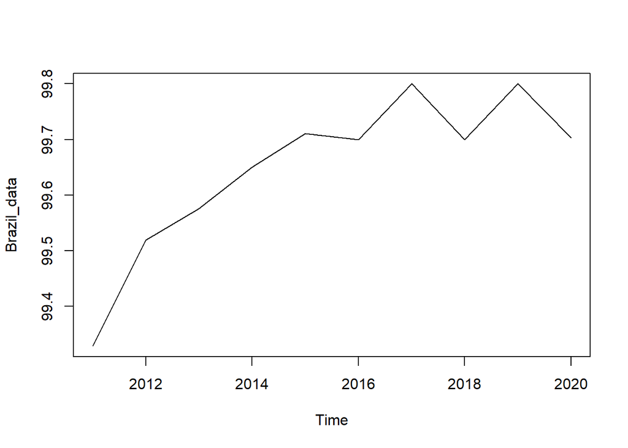

```r
plot(Brazil_data_series)
```

differentiate:

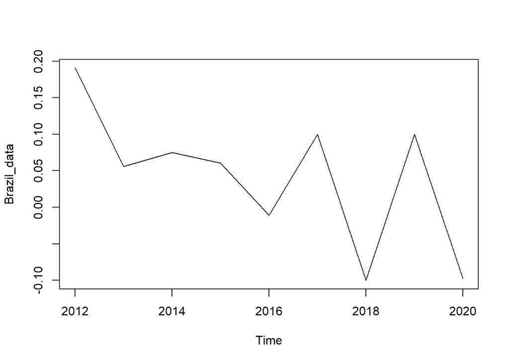

```r
Brazil_data_series_diff=diff(Brazil_data_series,differences = 1)
plot(Brazil_data_series_diff)
```

Check if the datat is stationary: h0 the data is not stationary h1 the data is stationary

below the p-value<0.05 so the data is stazionary after one differentiation

```r
library(tseries)
# Perform the Augmented Dickey-Fuller test
adf_result <- adf.test(Brazil_data_series_diff)
print(adf_result)
```

```
##
##  Augmented Dickey-Fuller Test
##
## data:  Brazil_data_series_diff
## Dickey-Fuller = -156.996742439855836, Lag order = 2, p-value = 0.01
## alternative hypothesis: stationary
```

*So now we have a stationary data differentiating one time*

If you need to difference your original time series data d times in order to obtain a stationary time series, this means that you can use an ARIMA(p,d,q) model for your time series, where d is the order of differencing used.

“So, an ARIMA(p,1,q) model is probably appropriate for the time series of Brazil’s access to electricity after differencing, as we have removed the trend component. and are left with an irregular component. We can now examine whether there are correlations between successive terms of this irregular component; if so, this could help us to make a predictive model for the access to electricity in Brazil.

**Selecting a Candidate ARIMA Model** If your time series is stationary, or if you have transformed it to a stationary time series by differencing d times, the next step is to select the appropriate ARIMA model, which means finding the values of most appropriate values of p and q for an ARIMA(p,d,q) model. To do this, you usually need to examine the correlogram and partial correlogram of the stationary time series. To plot a correlogram and partial correlogram, we can use the “acf()” and “pacf()” functions in R, respectively. To get the actual values of the autocorrelations and partial autocorrelations, we set “plot=FALSE” in the “acf()” and “pacf()” functions.

For autocorrelation we type:

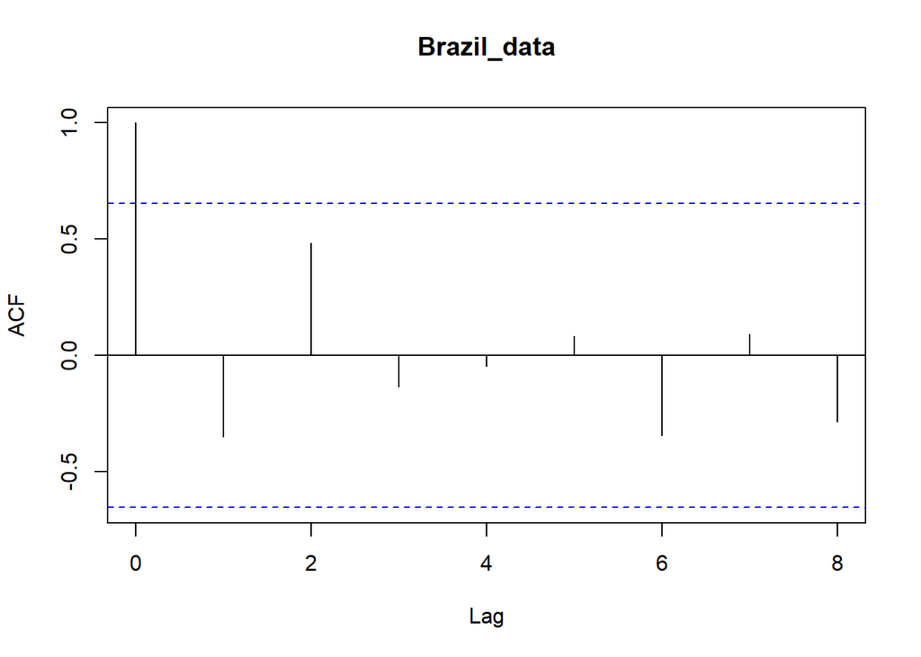

```r
acf(Brazil_data_series_diff,lag.max = 20)        #plot a correlogram
```

```r
acf(Brazil_data_series_diff,lag.max = 20,plot=F)
```

```
##
## Autocorrelations of series 'Brazil_data_series_diff', by lag
##
##      0      1      2      3      4      5      6      7      8
##  1.000 -0.350  0.482 -0.135 -0.046  0.083 -0.343  0.093 -0.284
```

We see from the correlogram that there is not autocorrelation that exceeds the significance bounds, between lags 1-8

To plot the partial correlogram for lags 1-8 for the once differenced time series of the Access to electricity in Brazil and get the values of the partial autocorrelations, we use the “pacf()” function, by typing:

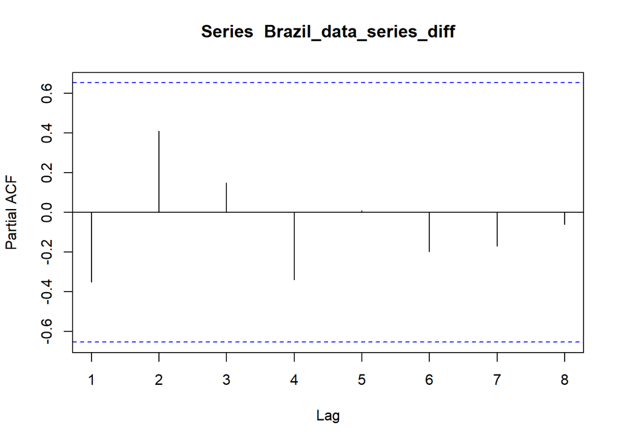

```r
pacf(Brazil_data_series_diff,lag.max = 20)
```

```r
pacf(Brazil_data_series_diff,lag.max = 20,plot=FALSE)
```

```
##
## Partial autocorrelations of series 'Brazil_data_series_diff', by lag
##
##      1      2      3      4      5      6      7      8
## -0.350  0.410  0.148 -0.339  0.009 -0.198 -0.170 -0.060
```

We see from the partial correlogram that there is not autocorrelation that exceeds the significance bounds, between lags 1-8

So given that correlogram and partial correlogram tail to 0 without exceding the the confidence interval we can set our model to ARIMA(0,1,0) where the 1 stand for the one time differentiation, the first 0 (no autoregressive terms(AR)) and the second 0 (no moving average terms (MA))

We can also use the shortcut provvided by R to get he same result:

```r
auto.arima(Brazil_data_series)
```

```
## Series: Brazil_data_series
## ARIMA(0,1,0)
##
## sigma^2 = 0.010919079524017914:  log likelihood = 8.0299999999999993605
## AIC=-14.070000000000000284   AICc=-13.5   BIC=-13.869999999999999218
```

*Forecasting Using an ARIMA Model* Once we have selected the best candidate ARIMA(p,d,q) model for your time series data, you can estimate the parameters of that ARIMA model, and use that as a predictive model for making forecasts for future values of your time series.

```r
Brazil_data_series_arima=arima(Brazil_data_series,order = c(0,1,0))
Brazil_data_series_arima
```

```
##
## Call:
## arima(x = Brazil_data_series, order = c(0, 1, 0))
##
##
## sigma^2 estimated as 0.0098228374140629706:  log likelihood = 8.0299999999999993605,  aic = -14.070000000000000284
```

```r
Brazil_data_series_forecast=forecast(Brazil_data_series_arima,h=5)
Brazil_data_series_forecast
```

```
##            Point Forecast                 Lo 80                 Hi 80
## 2021 99.70271300999999653 99.575698141370239114 99.829727878629753945
## 2022 99.70271300999999653 99.523086860160759670 99.882339159839233389
## 2023 99.70271300999999653 99.482716804216579476 99.922709215783413583
## 2024 99.70271300999999653 99.448683272740495909 99.956742747259497150
## 2025 99.70271300999999653 99.418699129590663688 99.986726890409329371
##                      Lo 95                  Hi 95
## 2021 99.508460531435375174  99.896965488564617885
## 2022 99.427998520289321505  99.977427499710671555
## 2023 99.366257847629896105 100.039168172370096954
## 2024 99.314208052870768029 100.091217967129225030
## 2025 99.268351263131691553 100.137074756868301506
```